# Part I - Superstore Dataset Exploration

## Introduction

Dataset containing Sales & Profit of a Superstore. This dataset can be found on [Kaggle](https://www.kaggle.com/datasets/vivek468/superstore-dataset-final?select=Sample+-+Superstore.csv)

For this project I will explore the dataset to understand which products, regions, categories and customer segments generate the highest and least sales, same for profit.

> **Metadata**

```
Row ID => Unique ID for each row.
Order ID => Unique Order ID for each Customer.
Order Date => Order Date of the product.
Ship Date => Shipping Date of the Product.
Ship Mode=> Shipping Mode specified by the Customer.
Customer ID => Unique ID to identify each Customer.
Customer Name => Name of the Customer.
Segment => The segment where the Customer belongs.
Country => Country of residence of the Customer.
City => City of residence of the Customer.
State => State of residence of the Customer.
Postal Code => Postal Code of every Customer.
Region => Region where the Customer belongs.
Product ID => Unique ID of the Product.
Category => Category of the product ordered.
Sub-Category => Sub-Category of the product ordered.
Product Name => Name of the Product
Sales => Sales of the Product.
Quantity => Quantity of the Product.
Discount => Discount provided.
Profit => Profit/Loss incurred.
```

### Exploration Link

1.Univariate Exploration

- Sales distribution
- Profit distribution
- Most ordered category of product
- Mostly ordered subcategory
- How product is ordered over the year
- Univariate Exploration Conclusion

2.Bivariate Exploration

- Relationship between sales, profit and quantity
- Category and shipped class used
- Most ordered category of product in each region
- Segment of buyers in each Region
- Sub-category and which category they belong to
- Sales made in each region
- Profit made in each region
- Sales made from each category
- Profit made from each category
- States with loss (negative profit)
- Bivariate Exploration Conclusion

3.Multivariate Exploration

- Display category on sales profit relationship
- Display region on sales profit relationship
- Display discount as size on sales profit relationship
- Average sales made from each category in each region

-Average profit made from each category in each region

- Total profit made from each sub-category in their category
- Total sales made from each sub-category in their category
- Relationship between sales and profit for each category
- Relationship between sales and profit for each region
- Relationship between sales and profit for each state with loss (i.e. states with negative profit)
- For each category, the relationship Between sales and profit in each region
- Average sales made from each segment for all category across each regions
- Average profit made from each segment for all category across each regions
- Average sales from each category across all state with loss
- Average profit from each category across all state with loss
- Multivariate Exploration Conclusion
- Conclusions

## Preliminary Wrangling

```python
# import all packages and set plots to be embedded inline
import numpy as np
import pandas as pd
import matplotlib.pyplot as plt
import seaborn as sb
from matplotlib import rcParams

%matplotlib inline
rcParams['figure.figsize'] = 8,5
plt.style.use('fivethirtyeight')
```

### Assessing Superstore Data

```python
# loading and previewing data

# the file should be loaded with "encoding='windows-1252" else you will
# encounter "UnicodeDecodeError"

store_data = pd.read_csv('Sample - Superstore.csv',encoding='windows-1252')
print(store_data.shape)
store_data.head(3)
```

```
(9994, 21)
```

|  | Row ID | Order ID | Order Date | Ship Date | Ship Mode | Customer ID | Customer Name | Segment | Country | City | ... | Postal Code | Region | Product ID | Category | Sub-Category | Product Name | Sales | Quantity | Discount | Profit |
| --- | --- | --- | --- | --- | --- | --- | --- | --- | --- | --- | --- | --- | --- | --- | --- | --- | --- | --- | --- | --- | --- |
| 0 | 1 | CA-2016-152156 | 11/8/2016 | 11/11/2016 | Second Class | CG-12520 | Claire Gute | Consumer | United States | Henderson | ... | 42420 | South | FUR-BO-10001798 | Furniture | Bookcases | Bush Somerset Collection Bookcase | 261.96 | 2 | 0.0 | 41.9136 |
| 1 | 2 | CA-2016-152156 | 11/8/2016 | 11/11/2016 | Second Class | CG-12520 | Claire Gute | Consumer | United States | Henderson | ... | 42420 | South | FUR-CH-10000454 | Furniture | Chairs | Hon Deluxe Fabric Upholstered Stacking Chairs,... | 731.94 | 3 | 0.0 | 219.5820 |
| 2 | 3 | CA-2016-138688 | 6/12/2016 | 6/16/2016 | Second Class | DV-13045 | Darrin Van Huff | Corporate | United States | Los Angeles | ... | 90036 | West | OFF-LA-10000240 | Office Supplies | Labels | Self-Adhesive Address Labels for Typewriters b... | 14.62 | 2 | 0.0 | 6.8714 |

3 rows × 21 columns

```python
# checking store information
store_data.info()
```

```
<class 'pandas.core.frame.DataFrame'>
RangeIndex: 9994 entries, 0 to 9993
Data columns (total 21 columns):
 #   Column         Non-Null Count  Dtype
---  ------         --------------  -----
 0   Row ID         9994 non-null   int64
 1   Order ID       9994 non-null   object
 2   Order Date     9994 non-null   object
 3   Ship Date      9994 non-null   object
 4   Ship Mode      9994 non-null   object
 5   Customer ID    9994 non-null   object
 6   Customer Name  9994 non-null   object
 7   Segment        9994 non-null   object
 8   Country        9994 non-null   object
 9   City           9994 non-null   object
 10  State          9994 non-null   object
 11  Postal Code    9994 non-null   int64
 12  Region         9994 non-null   object
 13  Product ID     9994 non-null   object
 14  Category       9994 non-null   object
 15  Sub-Category   9994 non-null   object
 16  Product Name   9994 non-null   object
 17  Sales          9994 non-null   float64
 18  Quantity       9994 non-null   int64
 19  Discount       9994 non-null   float64
 20  Profit         9994 non-null   float64
dtypes: float64(3), int64(3), object(15)
memory usage: 1.6+ MB
```

```python
# checking null values
store_data.isnull().sum()
```

```
Row ID           0
Order ID         0
Order Date       0
Ship Date        0
Ship Mode        0
Customer ID      0
Customer Name    0
Segment          0
Country          0
City             0
State            0
Postal Code      0
Region           0
Product ID       0
Category         0
Sub-Category     0
Product Name     0
Sales            0
Quantity         0
Discount         0
Profit           0
dtype: int64
```

```python
# sometimes, empty value are represented with "None"
# using "apply" to search for "None" in all dataframe columns

substring = 'none'
store_data[store_data.apply(lambda row: row.astype(str).str.contains(substring, case=False).any(),
                   axis=1)]
```

|  | Row ID | Order ID | Order Date | Ship Date | Ship Mode | Customer ID | Customer Name | Segment | Country | City | ... | Postal Code | Region | Product ID | Category | Sub-Category | Product Name | Sales | Quantity | Discount | Profit |
| --- | --- | --- | --- | --- | --- | --- | --- | --- | --- | --- | --- | --- | --- | --- | --- | --- | --- | --- | --- | --- | --- |

0 rows × 21 columns

```python
# checking for duplicates
store_data[store_data.duplicated()]
```

|  | Row ID | Order ID | Order Date | Ship Date | Ship Mode | Customer ID | Customer Name | Segment | Country | City | ... | Postal Code | Region | Product ID | Category | Sub-Category | Product Name | Sales | Quantity | Discount | Profit |
| --- | --- | --- | --- | --- | --- | --- | --- | --- | --- | --- | --- | --- | --- | --- | --- | --- | --- | --- | --- | --- | --- |

0 rows × 21 columns

```python
# checking summary of numerical columns
store_data.describe()
```

|  | Row ID | Postal Code | Sales | Quantity | Discount | Profit |
| --- | --- | --- | --- | --- | --- | --- |
| count | 9994.000000 | 9994.000000 | 9994.000000 | 9994.000000 | 9994.000000 | 9994.000000 |
| mean | 4997.500000 | 55190.379428 | 229.858001 | 3.789574 | 0.156203 | 28.656896 |
| std | 2885.163629 | 32063.693350 | 623.245101 | 2.225110 | 0.206452 | 234.260108 |
| min | 1.000000 | 1040.000000 | 0.444000 | 1.000000 | 0.000000 | -6599.978000 |
| 25% | 2499.250000 | 23223.000000 | 17.280000 | 2.000000 | 0.000000 | 1.728750 |
| 50% | 4997.500000 | 56430.500000 | 54.490000 | 3.000000 | 0.200000 | 8.666500 |
| 75% | 7495.750000 | 90008.000000 | 209.940000 | 5.000000 | 0.200000 | 29.364000 |
| max | 9994.000000 | 99301.000000 | 22638.480000 | 14.000000 | 0.800000 | 8399.976000 |

#### Issues

- column names not fit for programming
- erroneous data types (order date,ship date, ship mode, segment, postal_code, region, category,sub category)

### Cleaning Superstore Data

#### Making copy of original data

```python
# copy the original data
store_clean = store_data.copy()
```

#### Issue 1: Column name not fit for programming

#### Define: Change all column names to lower case and replace all empty space with an underscore.

#### Code

```python
# renaming columns to lower case with underscore in place of space and dash
store_clean.rename(columns=lambda x: x.strip().lower().replace(" ", "_"), inplace =True)
store_clean.rename(columns={'sub-category': 'sub_category'}, inplace=True)
store_clean.set_index('row_id',inplace=True)
```

#### Test

```python
# previewing
store_clean.head(2)
```

| row_id | order_id | order_date | ship_date | ship_mode | customer_id | customer_name | segment | country | city | state | postal_code | region | product_id | category | sub_category | product_name | sales | quantity | discount | profit |
| --- | --- | --- | --- | --- | --- | --- | --- | --- | --- | --- | --- | --- | --- | --- | --- | --- | --- | --- | --- | --- |
| 1 | CA-2016-152156 | 11/8/2016 | 11/11/2016 | Second Class | CG-12520 | Claire Gute | Consumer | United States | Henderson | Kentucky | 42420 | South | FUR-BO-10001798 | Furniture | Bookcases | Bush Somerset Collection Bookcase | 261.96 | 2 | 0.0 | 41.9136 |
| 2 | CA-2016-152156 | 11/8/2016 | 11/11/2016 | Second Class | CG-12520 | Claire Gute | Consumer | United States | Henderson | Kentucky | 42420 | South | FUR-CH-10000454 | Furniture | Chairs | Hon Deluxe Fabric Upholstered Stacking Chairs,... | 731.94 | 3 | 0.0 | 219.5820 |

### Issue 2: Erroneous data type (order date,ship date, ship mode, segment, postal_code, region, category,sub category)

#### Define: Change the above columns to their respective data type

#### Code

```python
# changing "order_date" and "ship_date" to datetime data type
date_col = ['order_date', 'ship_date']
store_clean[date_col] = store_clean[date_col].apply(pd.to_datetime)

# changing "ship_mode" to ordered categorical data type
ship_order = ['Same Day', 'First Class', 'Second Class', 'Standard Class']
store_clean['ship_mode'] = pd.Categorical(store_clean['ship_mode'],
                                                           ordered = True, categories = ship_order)

# changing "segment", "region", "category" and "sub_category" to category data type
cat_col = ['segment', 'region', 'category', 'sub_category']
store_clean[cat_col] = store_clean[cat_col].astype('category')

# changing "postal_code" to string data type
store_clean['postal_code'] = store_clean['postal_code'].astype(str)
```

#### Test

```python
# checking data information
store_clean.info()
```

```
<class 'pandas.core.frame.DataFrame'>
Int64Index: 9994 entries, 1 to 9994
Data columns (total 20 columns):
 #   Column         Non-Null Count  Dtype
---  ------         --------------  -----
 0   order_id       9994 non-null   object
 1   order_date     9994 non-null   datetime64[ns]
 2   ship_date      9994 non-null   datetime64[ns]
 3   ship_mode      9994 non-null   category
 4   customer_id    9994 non-null   object
 5   customer_name  9994 non-null   object
 6   segment        9994 non-null   category
 7   country        9994 non-null   object
 8   city           9994 non-null   object
 9   state          9994 non-null   object
 10  postal_code    9994 non-null   object
 11  region         9994 non-null   category
 12  product_id     9994 non-null   object
 13  category       9994 non-null   category
 14  sub_category   9994 non-null   category
 15  product_name   9994 non-null   object
 16  sales          9994 non-null   float64
 17  quantity       9994 non-null   int64
 18  discount       9994 non-null   float64
 19  profit         9994 non-null   float64
dtypes: category(5), datetime64[ns](2), float64(3), int64(1), object(9)
memory usage: 1.3+ MB
```

```python
# checking ship_mode ordered category
store_clean.ship_mode.unique()
```

```
['Second Class', 'Standard Class', 'First Class', 'Same Day']
Categories (4, object): ['Same Day' < 'First Class' < 'Second Class' < 'Standard Class']
```

#### DataFrame of unique value and value count for categorical columns.

```python
# This dataframe is to help show the number unique value in each categorical variable.
cat_col = ['ship_mode', 'segment', 'region', 'category', 'sub_category']
cat_unique = pd.DataFrame()
cat_unique['cat_col_name'] = cat_col
cat_unique['unique_values'] = cat_unique['cat_col_name'].apply(lambda x: store_clean[x].unique())
cat_unique['num_unique_values'] = cat_unique['cat_col_name'].apply(lambda x: store_clean[x].nunique())
cat_unique
```

|  | cat_col_name | unique_values | num_unique_values |
| --- | --- | --- | --- |
| 0 | ship_mode | ['Second Class', 'Standard Class', 'First Clas... | 4 |
| 1 | segment | ['Consumer', 'Corporate', 'Home Office'] Categ... | 3 |
| 2 | region | ['South', 'West', 'Central', 'East'] Categorie... | 4 |
| 3 | category | ['Furniture', 'Office Supplies', 'Technology']... | 3 |
| 4 | sub_category | ['Bookcases', 'Chairs', 'Labels', 'Tables', 'S... | 17 |

### What is the structure of your dataset?

> This dataset contains 9,994 entries of product sold with 20 fields that give details about the product such as; ship date, ship mode, region, product name, sales, quantity, profit, e.t.c.,There a five (5) categorical fields, ship mode being one of it is a ordered categorical type. Only four fields are numeric in nature, sales, quantity,discount, and profit.

### What is/are the main feature(s) of interest in your dataset?

> I'm interested in knowing which category is making the most sales, and if the category with the most sales is actually generating the highest profit. In the process, I'll get to know which states contribute most to this.

> I'm also interested in knowing the average sales and profit made from each category, region and segment.

> There is a loss (negative profit) in the dataset. I'm interested in knowing which states have loss, then investigate for more details and find out how the category contributes to the loss.

### What features in the dataset do you think will help support your investigation into your feature(s) of interest?

> Sales and profit will play a major role in my investigation, then these categories ship mode, segment, region, and category, will help narrow down the investigation for more details.

## Univariate Exploration

> BeforeI start exploring the dataset, I'm going to drop some columns that are redundant in my investigation.

> **Note**: All sales was made in the **United States**, thus the unit for sales and profit is in Dollars ($)

```python
# Making a copy of data for exploration.
store_sub = store_clean.copy()
```

```python
# Dropping redundant columns
redundant_col = ['order_id', 'customer_id','customer_id', 'country', 'city', 'postal_code',
                 'product_id', 'product_name']
store_sub.drop(redundant_col, inplace=True, axis =1)
```

#### Let's look at the sales distribution

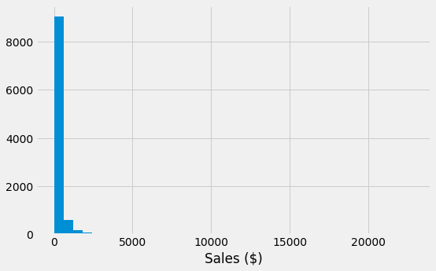

```python
# plotting sales histogram
bins = np.arange(store_sub.sales.min(), store_sub.sales.max()+600, 600)
plt.hist(data = store_sub, x = 'sales', bins = bins)
plt.xlabel('Sales ($)');
```

Sales has a long tail in the distribution, also, the frequency of sales from 5000 dollars are below 2000.

I will transform the scale to log.

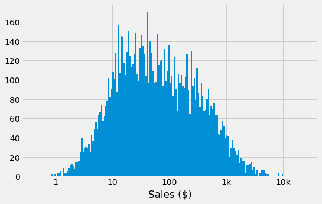

```python
# plottin sales with log scale
bins = 10 ** np.arange(-0.35, np.log10(store_sub.sales.max())+0.025, 0.025)
plt.hist(data = store_sub, x = 'sales', bins = bins)
plt.xscale('log')
plt.xticks([1, 10, 100, 1000, 10000],
           [1, 10, 100, '1k', '10k'])
plt.xlabel('Sales ($)');
```

Sales distribution, when plotted on a log scale, shows that the distribution is unimodal. The highest peak falls in the range of \$10 to $100.

#### Let's see how profit is distributed

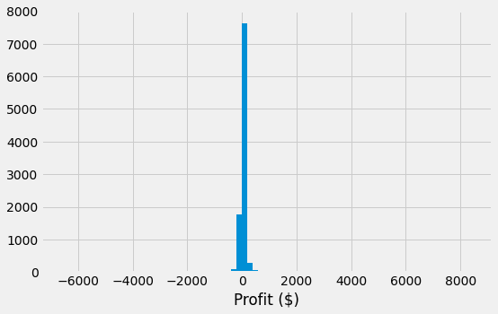

```python
# plotting profit histogram
bins = np.arange(store_sub.profit.min(), store_sub.profit.max()+200, 200)
plt.hist(data = store_sub, x = 'profit', bins = bins)
plt.xlabel('Profit ($)');
```

Profit has a long tail on both sides of the plot. There are negative values in the distribution.I will focus on the positive part of the profit since we can't perform log on negative values.

I'll plot again with a transform scale using log.

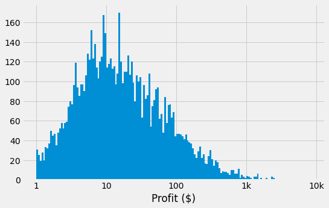

```python
# plottin profit with log scale
bins = 10 ** np.arange(0, np.log10(store_sub.profit.max())+0.025, 0.025)
plt.hist(data = store_sub, x = 'profit', bins = bins)
plt.xscale('log')
plt.xticks([1, 10, 100, 1000, 10000],
           ['1', '10', '100', '1k', '10k'])
plt.xlabel('Profit ($)');
```

The positive distribution of profit is unimodal in nature, with the highest peak below $50. We've seen the numeric side of the data, let's see the category part.

**Category Count**

Here we would see the most ordered category as well as sub-category.

```python
# Creating a function to create a countplot into a subplot for a given category variable.

color = sb.color_palette("Paired")[1]
def cat_count_plot(cat):
    if cat == 'ship_mode':
        sb.countplot(data = store_sub, x = cat, color = color )
        plt.xlabel('{}'.format(cat.replace("_"," ")));
    elif cat == 'sub_category':
        freq = store_sub[cat].value_counts()
        order = freq.index
        sb.countplot(data = store_sub, y = cat, color = color, order = order)
        plt.ylabel('{}'.format(cat.replace("_"," ")));
    else:
        freq = store_sub[cat].value_counts()
        order = freq.index
        sb.countplot(data = store_sub, x = cat, color = color, order = order)
        plt.xlabel('{}'.format(cat.replace("_"," ")));
```

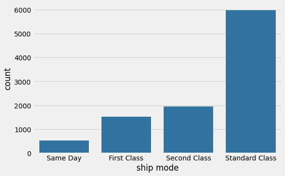

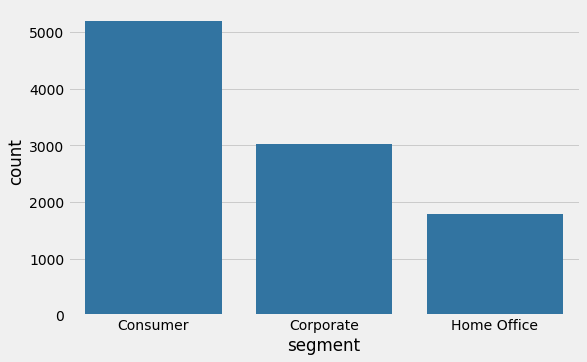

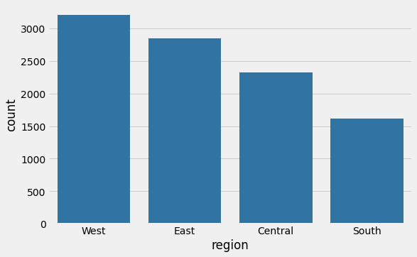

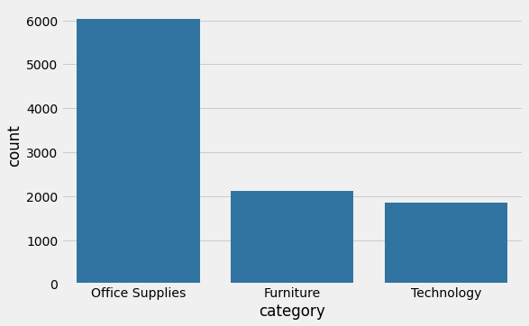

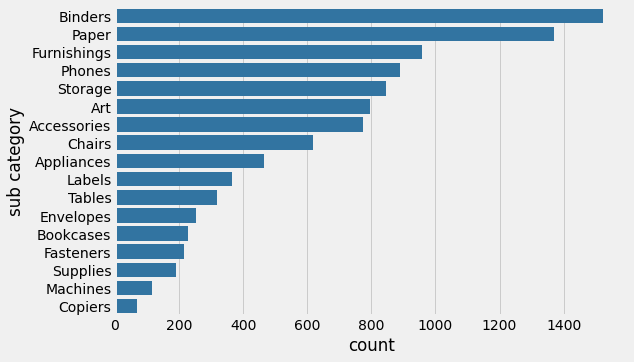

```python
# Iterating through a list of categorical variable for plotting.

cat_lst = ['ship_mode', 'segment', 'region', 'category', 'sub_category']
for cat_name in cat_lst:
    fig = plt.figure()
    fig.set_figwidth(18)
    fig.set_figheight(18)
    plt.subplot(3,2,1)
    cat_count_plot(cat_name)
```

Here's a brief note on ship mode. **Ship mode**: This field contains four unique values that depicts the duration it will take for the consumer to receive the product. Same Day: Shipping on Same Day First Class: Shipping within 1 Day Second Class: Shipping within 3 Days Standard Class: Shipping within 6 Days

From the plot, standard class is the most commonly used ship mode, this may be as a result of the majority customers being far from shop location, or cost of standard class. Home office is the least segment in the data.

Generally,the West has the highest count of products sold.

Interesting! Products in the Office Supply category are the most sold products. Furniture and Technology product bought is not up to half of product sold in the Office Supplies. In the sub category, Blinders has the highest count while Copiers has the least count.

**Is there an increase in products ordered over the year?**

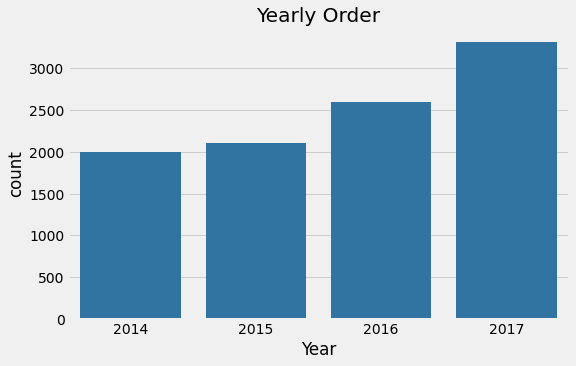

```python
# Create a order_year column with year of order
store_sub.insert(3, 'order_year', store_sub.order_date.dt.year)
sb.countplot(data = store_sub, x ='order_year', color = color)
plt.xlabel('Year')
plt.title('Yearly Order');
```

There is an increase in products being ordered as the year goes. Year 2017 has over 3,000 products ordered compared to 2014 that has below 2,000 orders.

### Discuss the distribution(s) of your variable(s) of interest. Were there any unusual points? Did you need to perform any transformations?

> The sales field when plotted on a standard histogram had a right skewed distribution, it also has a long tail of distribution so I used log transformation to plot the sales variable again. This time the data looked unimodal with the highest peak between \$10 and $100.

### Of the features you investigated, were there any unusual distributions? Did you perform any operations on the data to tidy, adjust, or change the form of the data? If so, why did you do this?s

> While investigating, I had to know how the product being ordered changed across the year so I generated a year column which changed the form of the data.

## Bivariate Exploration

> In this section, I will investigate relationships between pairs of variables in the data.

I will start by plotting the relationship between numeric variables in the data. then move on to category variables.

**Relationship between sales, profit and quantity**

Below is a function to plot the relationship between sales, profit and quantity.

```python
# A function to create a scatter plot for two numeric variable with conditions base on current data
def relationship(num_var1,num_var2):
    sb.regplot(data = store_sub, x= num_var1, y = num_var2, x_jitter = 0.05,
        scatter_kws = {'alpha':0.3, 's':30}, fit_reg = False)
    plt.title('{}'.format(num_var1 + ' vs ' + num_var2))
    if num_var1 == 'profit':
        plt.xlabel('{} ($)'.format(num_var1))
    elif num_var1 == 'sales':
        plt.xlabel('{} ($)'.format(num_var1))
    else:
        plt.xlabel('{}'.format(num_var1))

    if num_var2 == 'profit':
        plt.ylabel('{} ($)'.format(num_var2))
    elif num_var2 == 'sales':
        plt.ylabel('{} ($)'.format(num_var2))
    else:
        plt.ylabel('{}'.format(num_var2))
```

```python
# A function to create a scatter plot for two numeric variable with conditions base on current data
def log_relationship(num_var1,num_var2):
    sb.regplot(data = store_sub, x= num_var1, y = num_var2, x_jitter = 0.05,
        scatter_kws = {'alpha':0.3, 's':30}, fit_reg = False)
    plt.title('{}'.format(num_var1 + ' vs ' + num_var2))
    plt.yscale('symlog')
    plt.yticks([-1000, -100, -10, -1, 0, 1, 10, 100, 1000],
              ['-1k', '-100', '-10', '-1', '0', '1', '10', '100', '1000']);
    if num_var1 == 'profit':
        plt.xscale('symlog')
        plt.xticks([-1000, -100, -10, -1, 0, 1, 10, 100, 1000],
              ['-1k', '-100', '-10', '-1', '0', '1', '10', '100', '1000'])
        plt.xlabel('{} ($)'.format(num_var1))
    elif num_var1 == 'sales':
        plt.xscale('log')
        plt.xticks([1, 10, 100, 1000, 10000],['1', '10', '100', '1k', '10k'])
        plt.xlabel('{} ($)'.format(num_var1))
    else:
        plt.xlabel('{}'.format(num_var1))

    if num_var2 == 'profit':
        plt.yscale('symlog')
        plt.yticks([-1000, -100, -10, -1, 0, 1, 10, 100, 1000],
              ['-1k', '-100', '-10', '-1', '0', '1', '10', '100', '1000'])
        plt.ylabel('{} ($)'.format(num_var2))
    elif num_var2 == 'sales':
        plt.yscale('symlog')
        plt.yticks([-1000, -100, -10, -1, 0, 1, 10, 100, 1000],
              ['-1k', '-100', '-10', '-1', '0', '1', '10', '100', '1000'])
        plt.ylabel('{} ($)'.format(num_var2))
    else:
        plt.ylabel('{}'.format(num_var2))
```

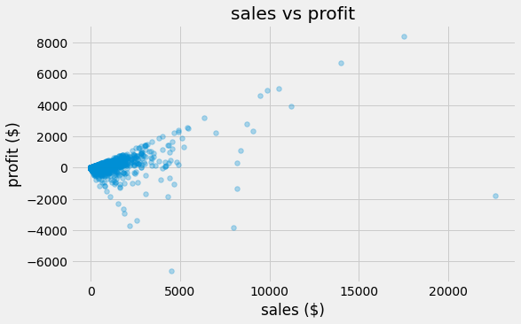

```python
relationship('sales','profit')
```

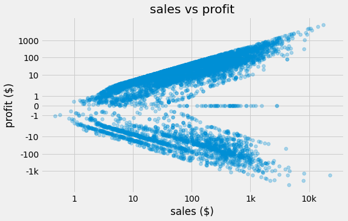

```python
log_relationship('sales', 'profit')
```

There is a positive and negative relationship between sales and profit. There are many clusters in the positive side of profit compared to the negative side meaning we have few losses. In the plot it is seen that the highest sale falls in the loss part of profit, thus we cannot say higher sales lead to high profit.

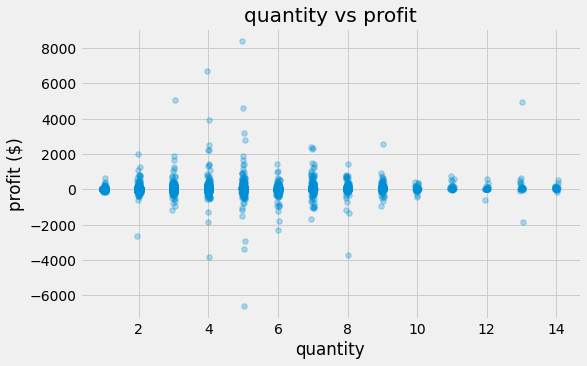

```python
relationship('quantity', 'profit')
```

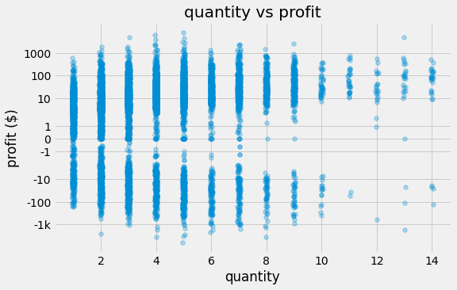

```python
log_relationship('quantity', 'profit')
```

Though there is positive and negative profit, the plot above shows that products quantity below 6 produce much profit as well as loss, on a higher frequency.

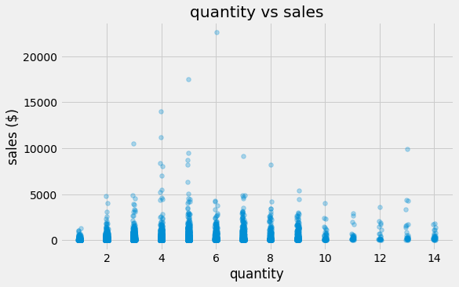

```python
relationship('quantity', 'sales')
```

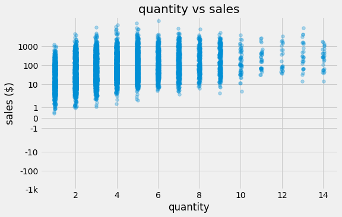

```python
log_relationship('quantity', 'sales')
```

Recall earlier in the sales profit relationship, we found out that the highest sales made loss, the plot above shows that the quantity of product for that sale is 6. Also there is only a positive relationship between sales and quantity

I'm going to use a plot matrix to display all relationships.

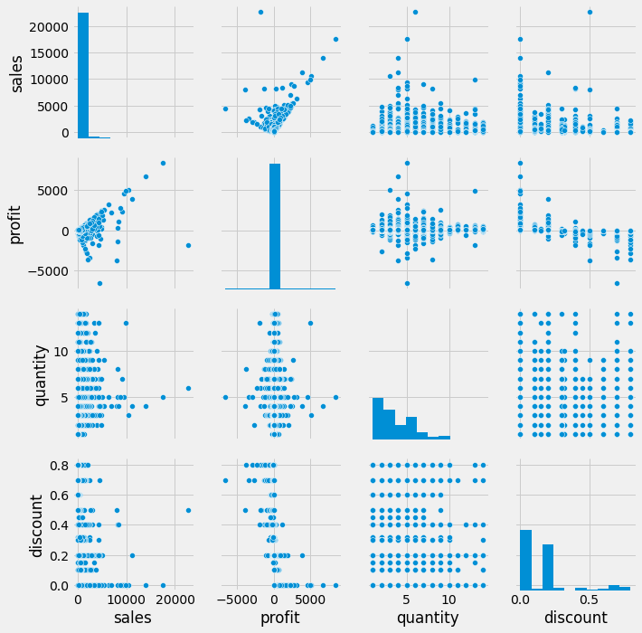

```python
num = ['sales', 'profit', 'quantity', 'discount']

g = sb.PairGrid(data = store_sub, vars = num)
g = g.map_offdiag(sb.scatterplot)
g.map_diag(plt.hist);
```

I decided to use Pairgrid to plot all numeric features in the data. I have already explained some part of it above. Well, it seems higher discounts result in loss and higher sales have low discounts.

Let's look at category and numeric data. First I'll look at how the quantity of product relates to the shipping mode chosen.

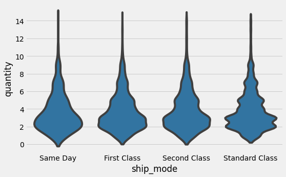

```python
# violin plot of quantity of product shipped in each mode.
sb.violinplot(data = store_sub, x = 'ship_mode', y = 'quantity',
              inner = None, color = color);
```

We have seen the quantity each ship class has, let's look at the product category and which ship class is used the most.

**Category and ship class used.**

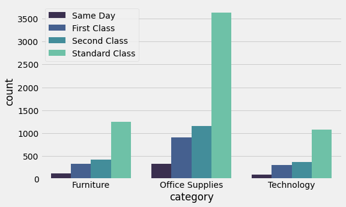

```python
sb.countplot(data=store_sub, x = 'category', hue = 'ship_mode',
             palette = 'mako')
plt.legend(loc='upper left');
```

Standard class is mostly used by customers and the plot above shows that Office Supplies products are shipped the most using this class.

Let's see the distribution of ship mode in each region.

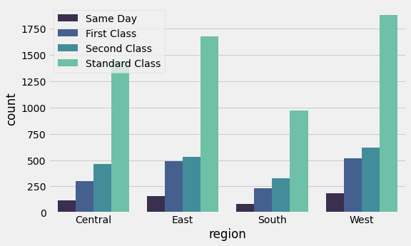

```python
sb.countplot(data=store_sub, x = 'region', hue = 'ship_mode',
             palette = 'mako')
plt.legend(loc='upper left');
```

Well, standard class ship mode is mostly used across all regions.

I'll now focus on my main feature of interest. Let's see how many products of a category were ordered for each region.

**Most ordered category of product in each region**

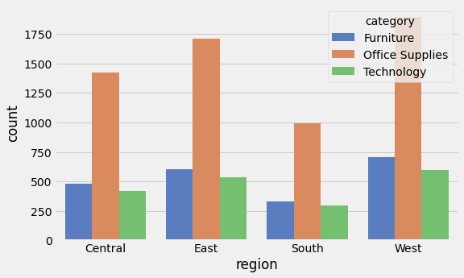

```python
sb.countplot(data=store_sub, x = 'region', hue = 'category',
             palette = 'muted');
```

The clustered bar chart shows how the category is distributed among the region, but the exact count is difficult to interpret. I will use a heatmap to plot again.

```python
def count_category(cat1, cat2):
    reg_cat = store_sub.groupby([cat1, cat2]).size()
    reg_cat = reg_cat.reset_index(name = 'count')
    reg_cat = reg_cat.pivot(index = cat1, columns = cat2,
                           values = 'count')
    sb.heatmap(reg_cat, annot = True, fmt = 'd', cmap = 'viridis_r',
              cbar_kws={'label': 'count'})
    plt.title('Count of each {} in each {}'.format(cat2, cat1));
```

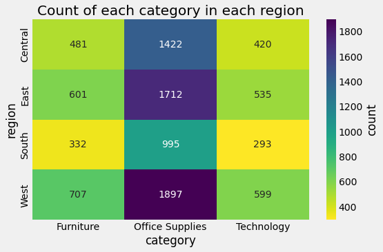

```python
count_category('region','category')
```

interesting! It looks like office supplies are the big deal here because its column alone has the highest for all regions. Generally, west happens to have the highest count of category, i.e. **1,897** is the highest count of category (Office Supplies) sold to one region, and that region is **West**.

We saw already in the univariate section that West is the region with the most ordered products, and the heatmap above did not just confirm that but shows how product categories contribute to this.

Let's find out how each segment contributes for each region.

**Segment of buyers in each Region**

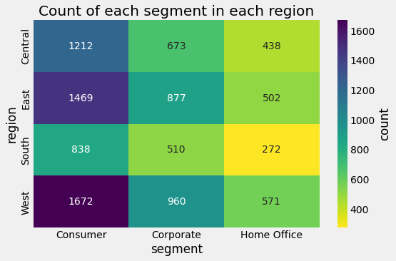

```python
count_category('region','segment')
```

It turns out that Consumer segment contributes the most, not only for West but the rest of the region, making it the segment that orders the most product as seen in the univariate section. It's also obvious that Consumer's segment purchases most of the Office Supplies we saw in the earlier heatmap.

For us to have a category and sub-category, it means that each product category has a unique sub-category. I also think that the number of product subcategories plays a role in why a category has the highest count and the other low count.

I'll use heatmap to display not just the sub-category in each category but the count of each of them.

**Sub-category and which category they belong to.**

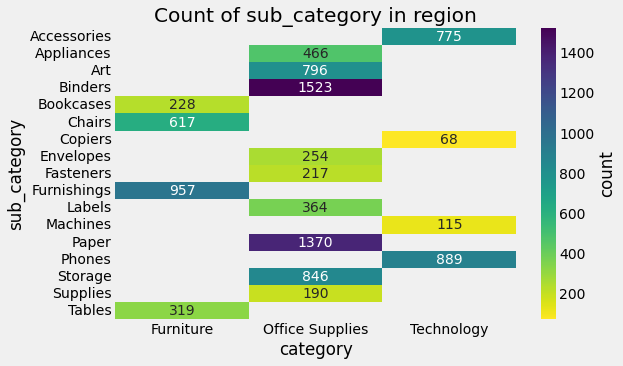

```python
reg_cat = store_sub.groupby(['category', 'sub_category']).size()
reg_cat = reg_cat.reset_index(name = 'count')
reg_cat = reg_cat.query('count > 0')
reg_cat = reg_cat.pivot(index = 'sub_category', columns = 'category',
                       values = 'count')
sb.heatmap(reg_cat, cmap = 'viridis_r', annot = True, fmt = '.0f',
          cbar_kws={'label': 'count'})
plt.title('Count of sub_category in region');
```

Wow! So it's because Office Supplies has much sub-category that is why it is the category with highest orders, and we saw in the univariate plot that Furniture and Technology were not up to half Office Supplies.

Blenders is the most ordered product in the Office Supplies sub-category, followed by Paper.

We have seen how the category is distributed among the region and the type of product in each sub-category. Let's look at the monetary part of the region and category.

**Sales made in each region**

I'm interested in knowing which category is making the most sales, and if the category with the most sales is actually generating the highest profit. In the process, I'll get to know which states contribute most to this.

```python
def barplot(num_var, cat_var):
    sb.barplot(data = store_sub, x= num_var, y = cat_var,
           color = color, errwidth = 0)
    plt.title('Average {} made in each {}'.format(num_var,cat_var))
    plt.xlabel('avg. {} ($)'.format(num_var));
```

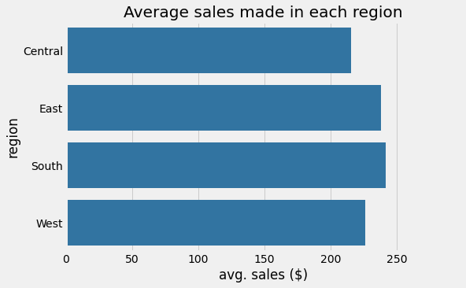

```python
barplot('sales', 'region')
```

The bar plot above shows the average sales made in each region. Not too long ago we saw that the West was dominating in terms of the number of products ordered, but the plot above shows that a higher number of products sold does not entail high sales. South generates the highest average sales followed by East.

Let's find out if high sales generate high profit.

**Profit made in each region**

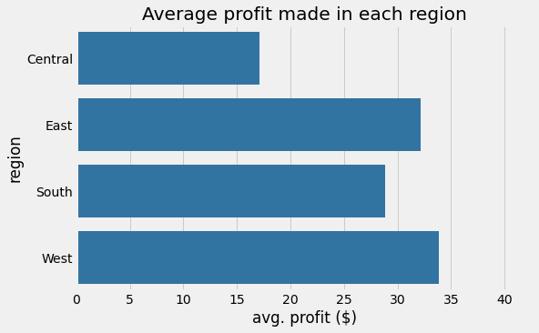

```python
barplot('profit', 'region')
```

The plot above depicts average profit made in each region. Though much sales were made in the South, it was not generating much profit. West, which was the third among the regions with high sales, generates the most profit.

Let's look at category sales

**Sales made from each Category**

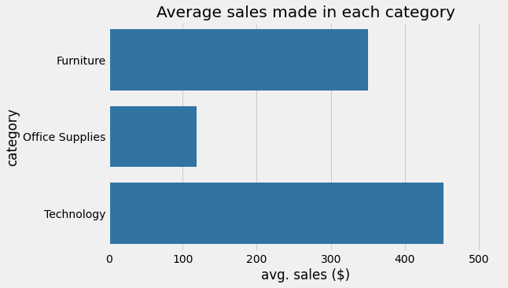

```python
barplot('sales', 'category')
```

Technology is leading in the section with average sales above \$400, followed by Furniture with average sales below $400.

Let's see the profit from each category

**Profit made from each category**

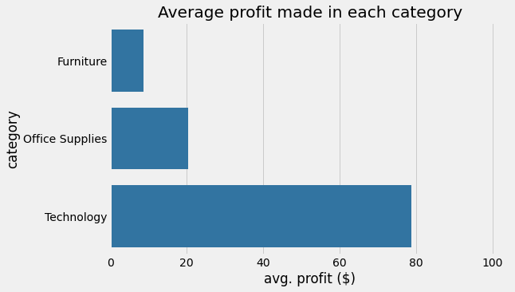

```python
barplot('profit', 'category')
```

Unlike region sales and profit, the Technology category made the highest sales and also the highest profit. Office Supplies which was the least in the previous plot is now the second category which made much profit, though it's not up to half of the first category (Technology).

It is now clear which category is generating the most profit, let's dig further and find out the top 5 states that buy this product the most.

```python
tech = store_sub.query('category == "Technology"')
```

```python
def TechStateDetails(num_var):
    tech_state = tech.groupby('state')[num_var].sum().sort_values(ascending = False)
    tech_state = tech_state.reset_index(name='{}_sum'.format(num_var))
    tech_state5 = tech_state.iloc[:5,:]
    return tech_state5
```

```python
TechStateDetails('quantity')
```

|  | state | quantity_sum |
| --- | --- | --- |
| 0 | California | 1405 |
| 1 | New York | 762 |
| 2 | Texas | 659 |
| 3 | Pennsylvania | 418 |
| 4 | Ohio | 384 |

The highest quantity of Technology products is sold to California. Let's check if California made the highest sales.

```python
TechStateDetails('sales')
```

|  | state | sales_sum |
| --- | --- | --- |
| 0 | California | 159271.082 |
| 1 | New York | 127483.500 |
| 2 | Texas | 65104.224 |
| 3 | Washington | 50536.710 |
| 4 | Florida | 46968.036 |

Yes, California made the highest sales but Pennsylvania and Ohio which made the top 5 earlier are not here. Washingnton and Florida made the top 5 states with technology sales.

Let's look at profit.

```python
TechStateDetails('profit')
```

|  | state | profit_sum |
| --- | --- | --- |
| 0 | New York | 42186.7856 |
| 1 | California | 29470.0368 |
| 2 | Washington | 15019.3435 |
| 3 | Indiana | 11000.8773 |
| 4 | Virginia | 7407.7544 |

So far, New York and California have maintained the first and second position amongst themselves. Washington climbed up to be the third state generating profit from technology products despite not being in the top 5 states that buys this product.

Let's briefly see the profit made in each state.

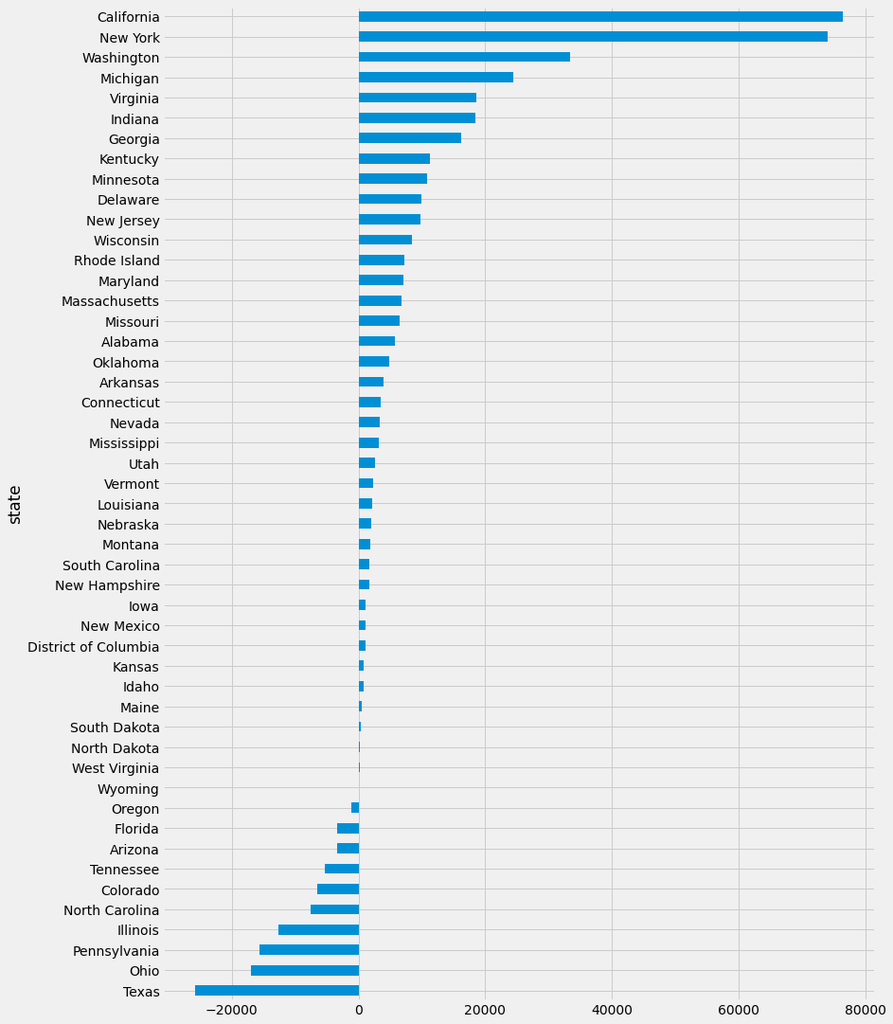

```python
plt.figure(figsize=(12,18))
state_prft = store_sub.groupby('state')['profit'].sum().sort_values()
state_prft.plot(kind = 'barh');
```

Over 5 states are generating negative profit. I'll dig further to know the exact count of states there are.

**States with Loss (negative profit)**

```python
state_prft = state_prft[:10]
state_prft_df = state_prft.reset_index(name='profit')
state_prft_df
```

|  | state | profit |
| --- | --- | --- |
| 0 | Texas | -25729.3563 |
| 1 | Ohio | -16971.3766 |
| 2 | Pennsylvania | -15559.9603 |
| 3 | Illinois | -12607.8870 |
| 4 | North Carolina | -7490.9122 |
| 5 | Colorado | -6527.8579 |
| 6 | Tennessee | -5341.6936 |
| 7 | Arizona | -3427.9246 |
| 8 | Florida | -3399.3017 |
| 9 | Oregon | -1190.4705 |

```python
state_prft_df = state_prft_df.sort_values('profit', ascending = False)
def barplot(num_var, cat_var):
    sb.barplot(data = state_prft_df, x= num_var, y = cat_var,
           color = color, errwidth = 0)
    plt.title('{} made in each loss {}'.format(num_var,cat_var))
    plt.xlabel('{} ($)'.format(num_var));
```

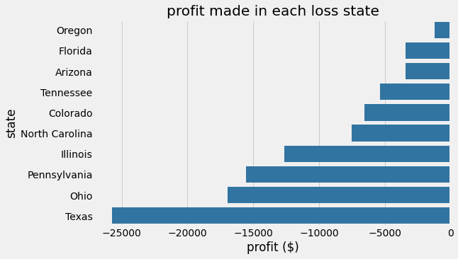

```python
barplot('profit', 'state')
```

A total of 10 states are made loss from the products. Texas has over $25,000 in losses. Let's see which region these states fall in the most.

```python
loss_state = [
    'Oregon', 'Florida', 'Arizona', 'Tennessee', 'Colorado',
    'North Carolina', 'Illinois', 'Pennsylvania', 'Ohio', 'Texas'
]
sub_state = store_sub.state.isin(loss_state)
LossState = store_sub.loc[sub_state]
```

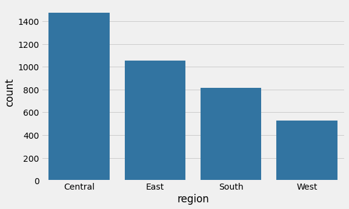

```python
sb.countplot(data = LossState, x = 'region', color = color);
```

The plot shows that the majority of these states are in the Central region. I will investigate more on these states in the next section.

### Talk about some of the relationships you observed in this part of the investigation. How did the feature(s) of interest vary with other features in the dataset?

> Sales has both a positive and negative relationship with profit, the negative is as a result of loss. South made the most sales but it turns out that South did not make the most profit, rather West made the most profit.

> Standard Class shipping mode is mostly used across all region

> The Office Supplies category is the most ordered category in the data. Majority of this product is ordered by the Consumer segment in the west.

> There are 10 states, Texas being the #1, that is not generating profit and most of these states are in the central region.

### Did you observe any interesting relationships between the other features (not the main feature(s) of interest)?

> It was obvious that each category has a unique sub-category, after plotting a heatmap, it was clear that Office Supplies which is the highest ordered category has 9 sub-categories compared to others which have 4 each.